# Reproducible Research: Assessment 1

Ray Lugo, Jr.

12 Feb 2017

## Purpose

To create a literate program that documents the methods used for data processing, analysis and visualization, provided in a form through which the research can be easily understood and reproduced.

## Prepare environment

### Load libraries.

The libraries used to create this literate program are : Tidyverse (includes Tidyr, dplyr, ggplot2, etc,) for data preparation and visualization, Lattice for additional visualizations, knitr to generate the markdown and HTML documents and XTable to facilitate the display tables in this document. Also, a custom CSS file (included in the repo) was used to modify the style for tables and other HTML elements.

```r
library(tidyverse)
library(lattice)
library(knitr)
library(xtable)
```

### Load data.

The data was loaded directly from ZIP archive using Readr’s read_csv function. This simplified data loading and saves disk space by eliminating the need to extract the data file.

```r
activity_data <- readr::read_csv(file = "data/activity.zip", col_names = TRUE,
    col_types = readr::cols(readr::col_integer(),
    readr::col_date(format = "%Y-%m-%d"),readr::col_integer()))
```

## Question 1: What is the mean total number of steps taken per day?

The first step towards answering this question requires a subset of the data which excludes any incomplete observations (excluding NA) and returns the sum of steps by date.

```r
activity_data_no_NA <- filter(activity_data,!is.na(activity_data$steps))
total_steps_per_day <- activity_data_no_NA %>%
    select(date, steps) %>%
    group_by(date) %>%
    summarise(totalSteps = sum(steps))
```

total_steps_per_day

|  | date | totalSteps |
| --- | --- | --- |
| 1 | 2012-10-02 | 126 |
| 2 | 2012-10-03 | 11352 |
| 3 | 2012-10-04 | 12116 |
| 4 | 2012-10-05 | 13294 |
| 5 | 2012-10-06 | 15420 |
| 6 | 2012-10-07 | 11015 |
| 7 | 2012-10-09 | 12811 |
| 8 | 2012-10-10 | 9900 |
| 9 | 2012-10-11 | 10304 |
| 10 | 2012-10-12 | 17382 |

Now we can plot the histogram of the **Total Steps per Day (totalSteps)** to visualize the distribution. To determine the number of bins which may be optimal for analysis, I’ve used the square root of the range of the variable, applying the ceiling method of rounding in order to get a whole number that is larger than the variable’s max value.

The bin-size will require a custom function or an existing package, however, since we only had one Histogram, I chose to divide the max value by the number of bins previously calculated and the result was rounded up to the next hundred, resulting in a bin width = 3,100.

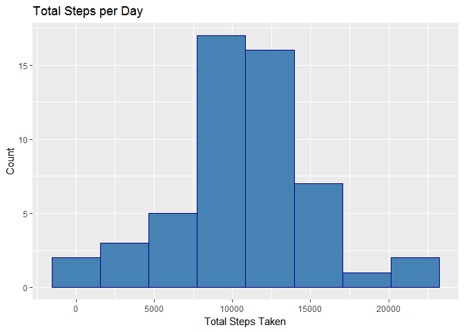

```r
numBins <- 1 + ceiling(sqrt(range(total_steps_per_day$totalSteps)))
binSize <- 3100

plot_histogram_total_steps_per_day <- ggplot(data = total_steps_per_day, aes(x = totalSteps)) +
    geom_histogram(stat = "bin", bins = numBins, binwidth = binSize, color = "darkblue", fill = "steelblue") +
    labs(title = "Total Steps per Day", x = "Total Steps Taken", y = "Count") +
    ggsave(filename = "figures/histogram_total_steps_per_day.png", width = 5, height = 3)

plot_histogram_total_steps_per_day
```

Although we can visually identify that the bins with the largest number of values are in the center of the graph, those 2 bins can account for up to 6,200 values so it is highly unlikely that we can guess the exact value at the center of the distribution. We can, however, determine the central value by calculating the measures of central tendency.

The Mean and Median values are measures of central tendency and comparing the two would allow us to gauge the strength or weakness of the central tendency for this distribution. This being the latter case, the comparison of Mean and Median values would provide us with the amount of variation or size and direction of skew. As the skew increases the histogram leans to one side or the other. This make finding a valid center difficult, perhaps preventing any adjustment to the data which could create the balance needed for a strong central tendency. This leads to choosing the best measure of central tendency between Mean, Median and Mode for the given application of the distribution (Discrete or Continuous, etc.)

First, calculate the **Mean** value of **totalSteps**.

```r
meanTotalSteps <- mean(total_steps_per_day$totalSteps)
print(paste("Mean total steps per day:", meanTotalSteps))
```

```
## [1] "Mean total steps per day: 10766.1886792453"
```

Then, calculate the **Median** value of **totalSteps**.

```r
###calculate the mid value of total steps
midTotalSteps <- median(total_steps_per_day$totalSteps)
print(paste("Median total steps per day:", midTotalSteps))
```

```
## [1] "Median total steps per day: 10765"
```

*There is a very small difference between the Mean and Median which prevents this from being true symmetric distribution.*

## Question 2: What is the average daily activity pattern?

Create a subset from the original dataset, minus the incomplete observations, and group the subset by interval, calculating the average of the number of steps in each interval. The result is a dataset with interval and meanSteps, across all date values. Date is not a grouping in this set, it is ignored in order to focus on the relationship of the interval and average of the number of steps.

```r
mean_steps_per_interval_all_days <- activity_data_no_NA %>%
    select(interval, steps) %>%
    group_by(interval) %>%
    summarise(meanSteps = mean(steps))
```

mean_steps_per_interval_all_days

|  | interval | meanSteps |
| --- | --- | --- |
| 1 | 0 | 1.72 |
| 2 | 5 | 0.34 |
| 3 | 10 | 0.13 |
| 4 | 15 | 0.15 |
| 5 | 20 | 0.08 |
| 6 | 25 | 2.09 |
| 7 | 30 | 0.53 |
| 8 | 35 | 0.87 |
| 9 | 40 | 0.00 |
| 10 | 45 | 1.47 |

Create the timeseries plot using the interval as the x value and the meanSteps as the continuous y value.

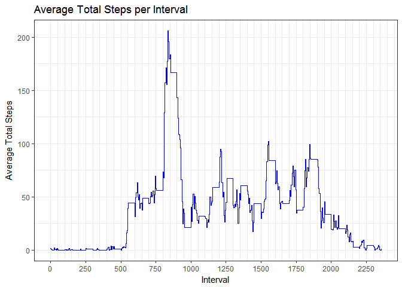

```r
plot_time_series_mean_steps_per_interval <- ggplot(data = mean_steps_per_interval_all_days, aes(interval, meanSteps)) +
    geom_step(color = 'blue', lwd = 0.25) +
    scale_x_continuous(breaks = c(seq(0,2500,250)),minor_breaks = c(seq(0,2500,50))) +
    theme_bw() +
    labs(title = "Average Total Steps per Interval", x = "Interval", y = "Average Total Steps") +
    ggsave(filename = "figures/time_series_mean_steps_per_interval.png", width = 5, height = 3)

plot_time_series_mean_steps_per_interval
```

To identify the interval with the highest average steps per day, filter the data set to get the interval with the MAX meanSteps value.

```r
interval_max_steps = mean_steps_per_interval_all_days %>%
    select(interval, meanSteps) %>%
    filter(meanSteps == max(meanSteps))

print(paste("Interval #",interval_max_steps$interval,"has the max average steps per day of", interval_max_steps$meanSteps))
```

```
## [1] "Interval # 835 has the max average steps per day of 206.169811320755"
```

Plot a red vertical line, red point on the value and label both to identify the interval with max steps on the timeseries visualization.

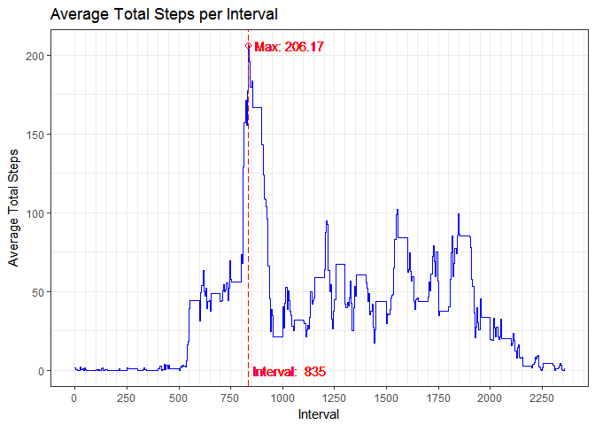

```r
plot_time_series_interval_max_steps = plot_time_series_mean_steps_per_interval +
    geom_vline(xintercept = interval_max_steps$interval, color = "red", lwd = 0.1, linetype = "longdash") +
    geom_point(x = interval_max_steps$interval, y = interval_max_steps$meanSteps, pch = 21, size = 2, color = "red") +
    labs(title = "Average Total Steps per Interval ", x = "Interval", y = "Average Total Steps") +
    geom_text(aes(x  = interval_max_steps$interval, y = 0), nudge_x = 200, size = 4, label = paste("Interval: ",interval_max_steps$interval), color = "red") +
    geom_text(aes(x  = interval_max_steps$interval, y = interval_max_steps$meanSteps), nudge_x = 200, size = 4, label = paste("Max:", round(interval_max_steps$meanSteps,2)), color = "red") +
    ggsave(filename = "figures/time_series_interval_max_steps.png", width = 5, height = 3)

plot_time_series_interval_max_steps
```

## Question 3: Which method can be used for Imputing missing values.

Create a subset of the incomplete observations from the original dataset. Then, calculate and report the number of missing values.

```r
missing_activity_data <- filter(activity_data,is.na(activity_data$steps))
print(paste("Number of Observations missing data:", count(missing_activity_data)))
```

```
## [1] "Number of Observations missing data: 2304"
```

missing_activity_data

|  | steps | date | interval |
| --- | --- | --- | --- |
| 1 |  | 2012-10-01 | 0 |
| 2 |  | 2012-10-01 | 5 |
| 3 |  | 2012-10-01 | 10 |
| 4 |  | 2012-10-01 | 15 |
| 5 |  | 2012-10-01 | 20 |
| 6 |  | 2012-10-01 | 25 |
| 7 |  | 2012-10-01 | 30 |
| 8 |  | 2012-10-01 | 35 |
| 9 |  | 2012-10-01 | 40 |
| 10 |  | 2012-10-01 | 45 |

The strategy used to impute values in the incomplete observations is to replace the NA with previously calculated average total steps value for each respective interval. This can be done by joining the dataset of incomplete observations with the dataset of average total steps using the interval value which is in both datasets. Then we can create a dataset with the replacement values.

```r
imputed_activity_data <- inner_join(missing_activity_data, mean_steps_per_interval_all_days, by = "interval") %>%
    select(steps = meanSteps, date,interval)
```

imputed_activity_data

|  | steps | date | interval |
| --- | --- | --- | --- |
| 1 | 1.72 | 2012-10-01 | 0 |
| 2 | 0.34 | 2012-10-01 | 5 |
| 3 | 0.13 | 2012-10-01 | 10 |
| 4 | 0.15 | 2012-10-01 | 15 |
| 5 | 0.08 | 2012-10-01 | 20 |
| 6 | 2.09 | 2012-10-01 | 25 |
| 7 | 0.53 | 2012-10-01 | 30 |
| 8 | 0.87 | 2012-10-01 | 35 |
| 9 | 0.00 | 2012-10-01 | 40 |
| 10 | 1.47 | 2012-10-01 | 45 |

A new dataset is then created using the rows from the original dataset, minus the incomplete observations and appending the rows from the imputed, replacement dataset.

```r
revised_activity_data <- rbind(activity_data_no_NA, imputed_activity_data)
```

revised_activity_data

[output not shown]

This dataset will need to be grouped by date and sum the steps to create the necessary totalSteps per day data required for the histogram.

```r
revised_total_steps_per_day <- revised_activity_data %>%
    select(date, steps) %>%
    group_by(date) %>%
    summarise(totalSteps = sum(steps))
```

revised_total_steps_per_day

|  | date | totalSteps |
| --- | --- | --- |
| 1 | 2012-10-01 | 10766.19 |
| 2 | 2012-10-02 | 126.00 |
| 3 | 2012-10-03 | 11352.00 |
| 4 | 2012-10-04 | 12116.00 |
| 5 | 2012-10-05 | 13294.00 |
| 6 | 2012-10-06 | 15420.00 |
| 7 | 2012-10-07 | 11015.00 |
| 8 | 2012-10-08 | 10766.19 |
| 9 | 2012-10-09 | 12811.00 |
| 10 | 2012-10-10 | 9900.00 |

Then, create the histogram of the total number of steps taken each day using the newly created, aggregated, “complete” dataset.

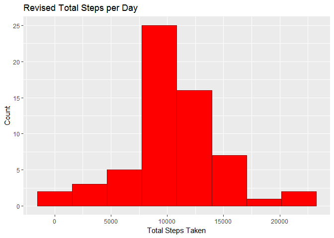

```r
numBins <- 1 + ceiling(sqrt(range(revised_total_steps_per_day$totalSteps)))
binSize <- 3100

plot_histogram_revised_total_steps_per_day <- ggplot(data = revised_total_steps_per_day, aes(totalSteps)) +
    geom_histogram(stat = "bin", bins = numBins, binwidth = binSize, color = "darkred", fill = "red") +
    labs(title = "Revised Total Steps per Day", x = "Total Steps Taken", y = "Count") +
    ggsave(filename = "figures/histogram_revised_total_steps_per_day.png", width = 5, height = 3)

plot_histogram_revised_total_steps_per_day
```

Again, calculate the **Mean** value of total steps

```r
revisedMeanTotalSteps <- mean(revised_total_steps_per_day$totalSteps)
print(paste("Revised Mean total steps per day:", revisedMeanTotalSteps))
```

```
## [1] "Revised Mean total steps per day: 10766.1886792453"
```

calculate the **Median** value of total steps.

```r
revisedMidTotalSteps <- median(revised_total_steps_per_day$totalSteps)
print(paste("Revised Median total steps per day:", revisedMidTotalSteps))
```

```
## [1] "Revised Median total steps per day: 10766.1886792453"
```

### Do the values differ from the original mean and mid?

Yes, the Median and the Mean are equal which means this is a symmetric distribution.

### What is the impact of imputing missing data on the estimates of the total daily number of steps?

To be thorough in our answer, we need to calculate the final measure of central tendency, the Mode, which will allow us to further test the strength of the central distribution.

```r
#getmode function was found here https://www.tutorialspoint.com/r/r_mean_median_mode.htm
getmode <- function(v) {
    uniqv <- unique(v)
    uniqv[which.max(tabulate(match(v, uniqv)))]
}

revisedMode <- getmode(revised_total_steps_per_day$totalSteps)
print(paste("The Mode of averaged total steps per day:", revisedMode))
```

```
## [1] "The Mode of averaged total steps per day: 10766.1886792453"
```

The **Mean** value is now equal to the **Median** value, so the slight skewness that was present initially has been corrected by replacing the missing values with the average total daily steps at each interval.

## Question #4: Are there differences in activity patterns between weekdays and weekends?

To answer this, I created a vectorized function, necessary for compatibility with dplyr functions, to determine the day of week using the function “weekdays()” on the date value and then return either “weekday” or “weekend”.

```r
determineDayType <- function(x) {
    dayOfWeek <- weekdays(x, FALSE)
    ifelse(is.element(dayOfWeek,c("Saturday","Sunday")),return("weekend"),return("weekday"))
}

vdetermineDayType <- Vectorize(determineDayType)
```

Then, using mutate(), create and populate a new column in the revised dataset to hold the results of the new function, vdetermineDayType(date).

```r
dayType_activity_data <- mutate(revised_activity_data, dayType = vdetermineDayType(revised_activity_data$date))

### make the column a factor with 2 levels.
dayType_activity_data$dayType <- as.factor(dayType_activity_data$dayType)
```

dayType_activity_data

|  | steps | date | interval | dayType |
| --- | --- | --- | --- | --- |
| 1 | 0.00 | 2012-10-02 | 0 | weekday |
| 2 | 0.00 | 2012-10-02 | 5 | weekday |
| 3 | 0.00 | 2012-10-02 | 10 | weekday |
| 4 | 0.00 | 2012-10-02 | 15 | weekday |
| 5 | 0.00 | 2012-10-02 | 20 | weekday |
| 6 | 0.00 | 2012-10-02 | 25 | weekday |
| 7 | 0.00 | 2012-10-02 | 30 | weekday |
| 8 | 0.00 | 2012-10-02 | 35 | weekday |
| 9 | 0.00 | 2012-10-02 | 40 | weekday |
| 10 | 0.00 | 2012-10-02 | 45 | weekday |

Prepare the data for visualization of the answer, grouping by the interval and Type of Day (weekend or weekday) and calculate the mean of the total steps for each group combination.

```r
### Calculate average steps by dayType and interval
dayType_Mean_Total_Steps_by_Interval <- dayType_activity_data %>%
    group_by(dayType, interval) %>%
    summarise(meanSteps = mean(steps))
```

dayType_Mean_Total_Steps_by_Interval

|  | dayType | interval | meanSteps |
| --- | --- | --- | --- |
| 1 | weekday | 0 | 2.25 |
| 2 | weekday | 5 | 0.45 |
| 3 | weekday | 10 | 0.17 |
| 4 | weekday | 15 | 0.20 |
| 5 | weekday | 20 | 0.10 |
| 6 | weekday | 25 | 1.59 |
| 7 | weekday | 30 | 0.69 |
| 8 | weekday | 35 | 1.14 |
| 9 | weekday | 40 | 0.00 |
| 10 | weekday | 45 | 1.80 |

Plot using “lattice” to create a visualization with facets, one over the other for simple visual comparison.

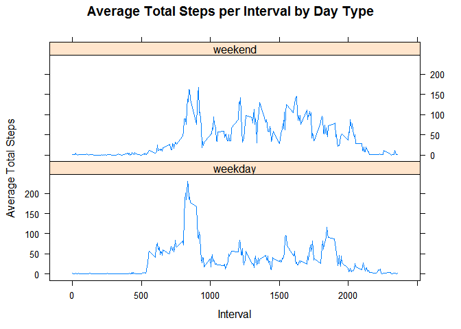

```r
time_series_mean_steps_interval_dayType <-  xyplot(meanSteps ~ interval|dayType, data = dayType_Mean_Total_Steps_by_Interval, type = "l", layout = c(1,2), xlab = "Interval", ylab = "Average Total Steps", main = "Average Total Steps per Interval by Day Type")
#plot(time_series_mean_steps_interval_dayType)
#note: lattice can only save to the current working directory (unless I missed something), so added steps to change to "figures" dir and then back.
time_series_mean_steps_interval_dayType
```

We can see from the comparison of the two visualizations that the subject’s pattern has a slight shift to the right on weekends. Based on the average observations, they are more active later in the morning and remain very active until later at night on a weekend than on weekdays.

The weekday displays a higher level of activity at first, then a rapid and severe drop in activity that remains low to moderate for the duration of the day and night, leading to an earlier drop in activity in the last intervals, slowing activity much sooner than during the weekend.

Next steps for analysis would be to tie the intervals to the 24 hour time in order to see the activity through the day with the time as reference points. An understanding of the types of activity that generate higher levels would provide more insight as to the subject’s average daily patterns on the weekday vs. the weekend.